# Tidyverse: ggplot

Bernard Ade

10-18-2016

ggplot is a powerful data visualization library created by Hadley Wickham. gglot is based on the grammar of graphics which outlines a universal grammar to build plots. This post picks up where the previous post about dplyr ended. I will demonstate the power of combining dplyr and ggplot to create insightful graphs.

`r`r library(dplyr) library(ggplot2) library(lubridate) library(scales) superstore = read.csv(‘superstore.csv’) superstore = superstore %>% mutate(`Order.Date` = mdy(`Order.Date`)) superstore = superstore %>% mutate(`Ship.Date` = mdy(`Ship.Date`))

### Dataset

`r`r superstore

| Row.ID | Order.ID | Order.Date | Ship.Date | Ship.Mode | Customer.ID | Customer.Name | Segment | Country | City | State | Postal.Code | Region | Product.ID | Category | Sub.Category | Product.Name | Sales | Quantity | Discount | Profit |
| --- | --- | --- | --- | --- | --- | --- | --- | --- | --- | --- | --- | --- | --- | --- | --- | --- | --- | --- | --- | --- |
| 1 | CA-2013-152156 | 2013-11-09 | 2013-11-12 | Second Class | CG-12520 | Claire Gute | Consumer | United States | Henderson | Kentucky | 42420 | South | FUR-BO-10001798 | Furniture | Bookcases | Bush Somerset Collection Bookcase | 261.9600 | 2 | 0.00 | 41.9136 |
| 2 | CA-2013-152156 | 2013-11-09 | 2013-11-12 | Second Class | CG-12520 | Claire Gute | Consumer | United States | Henderson | Kentucky | 42420 | South | FUR-CH-10000454 | Furniture | Chairs | Hon Deluxe Fabric Upholstered Stacking Chairs, Rounded Back | 731.9400 | 3 | 0.00 | 219.5820 |
| 3 | CA-2013-138688 | 2013-06-13 | 2013-06-17 | Second Class | DV-13045 | Darrin Van Huff | Corporate | United States | Los Angeles | California | 90036 | West | OFF-LA-10000240 | Office Supplies | Labels | Self-Adhesive Address Labels for Typewriters by Universal | 14.6200 | 2 | 0.00 | 6.8714 |
| 4 | US-2012-108966 | 2012-10-11 | 2012-10-18 | Standard Class | SO-20335 | Sean O'Donnell | Consumer | United States | Fort Lauderdale | Florida | 33311 | South | FUR-TA-10000577 | Furniture | Tables | Bretford CR4500 Series Slim Rectangular Table | 957.5775 | 5 | 0.45 | -383.0310 |
| 5 | US-2012-108966 | 2012-10-11 | 2012-10-18 | Standard Class | SO-20335 | Sean O'Donnell | Consumer | United States | Fort Lauderdale | Florida | 33311 | South | OFF-ST-10000760 | Office Supplies | Storage | Eldon Fold 'N Roll Cart System | 22.3680 | 2 | 0.20 | 2.5164 |
| 6 | CA-2011-115812 | 2011-06-09 | 2011-06-14 | Standard Class | BH-11710 | Brosina Hoffman | Consumer | United States | Los Angeles | California | 90032 | West | FUR-FU-10001487 | Furniture | Furnishings | Eldon Expressions Wood and Plastic Desk Accessories, Cherry Wood | 48.8600 | 7 | 0.00 | 14.1694 |
| 7 | CA-2011-115812 | 2011-06-09 | 2011-06-14 | Standard Class | BH-11710 | Brosina Hoffman | Consumer | United States | Los Angeles | California | 90032 | West | OFF-AR-10002833 | Office Supplies | Art | Newell 322 | 7.2800 | 4 | 0.00 | 1.9656 |
| 8 | CA-2011-115812 | 2011-06-09 | 2011-06-14 | Standard Class | BH-11710 | Brosina Hoffman | Consumer | United States | Los Angeles | California | 90032 | West | TEC-PH-10002275 | Technology | Phones | Mitel 5320 IP Phone VoIP phone | 907.1520 | 6 | 0.20 | 90.7152 |
| 9 | CA-2011-115812 | 2011-06-09 | 2011-06-14 | Standard Class | BH-11710 | Brosina Hoffman | Consumer | United States | Los Angeles | California | 90032 | West | OFF-BI-10003910 | Office Supplies | Binders | DXL Angle-View Binders with Locking Rings by Samsill | 18.5040 | 3 | 0.20 | 5.7825 |
| 10 | CA-2011-115812 | 2011-06-09 | 2011-06-14 | Standard Class | BH-11710 | Brosina Hoffman | Consumer | United States | Los Angeles | California | 90032 | West | OFF-AP-10002892 | Office Supplies | Appliances | Belkin F5C206VTEL 6 Outlet Surge | 114.9000 | 5 | 0.00 | 34.4700 |

[output cut: 990 more lines]

### Line graph

Basic line graph showing sum of sales by year.

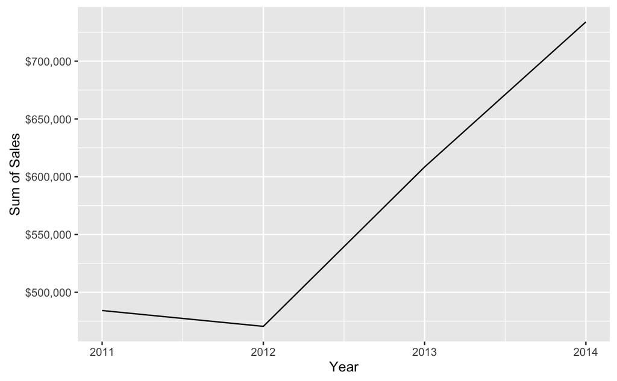

### Bar plot

Basic bar graph showing sum of sales by year.

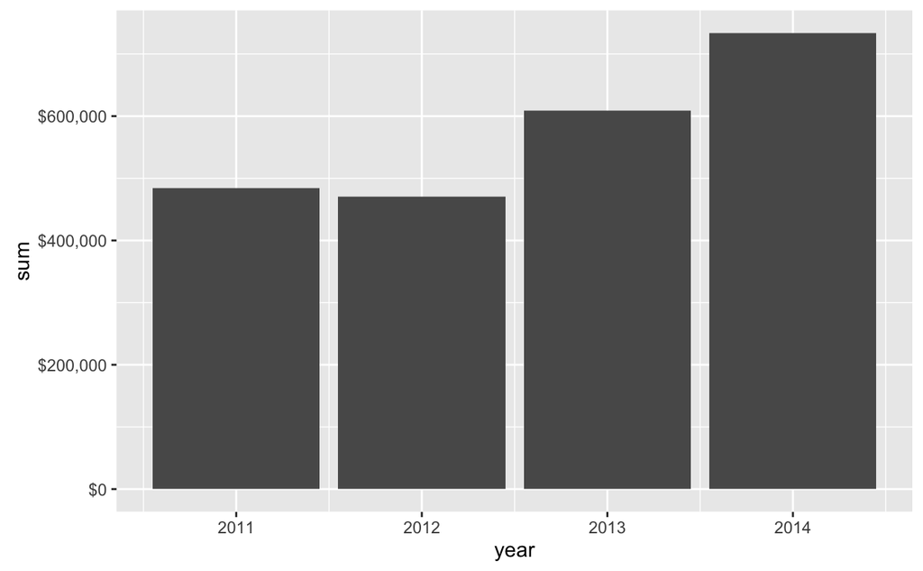

### Area Chart

Basic area graph showing sum of sales by year.

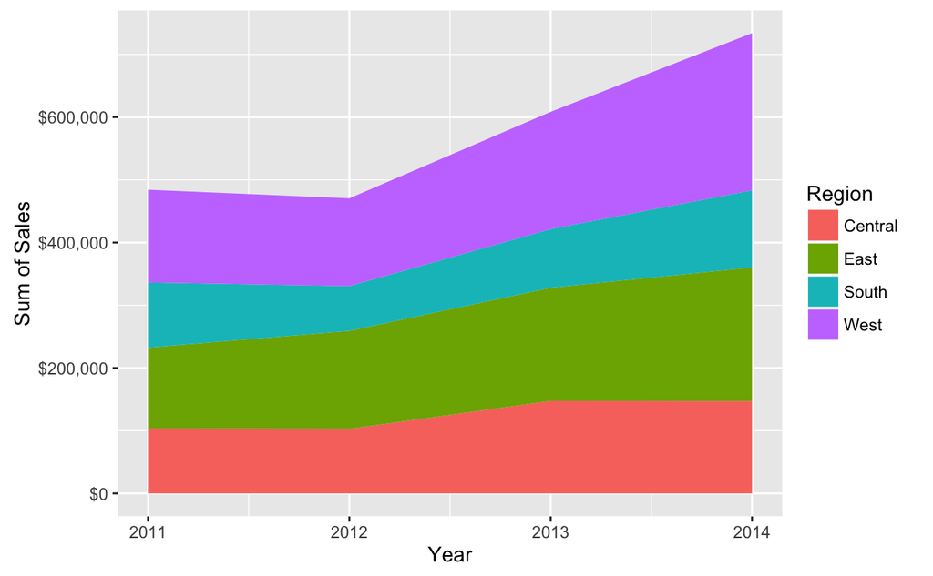

### Scatter Plot

Basic scatter plot showing relationship between Sales and Profit.

`r`r superstore %>% ggplot(aes(Sales, Profit)) + geom_point() + scale_y_continuous(labels = dollar) + scale_x_continuous(labels = dollar)

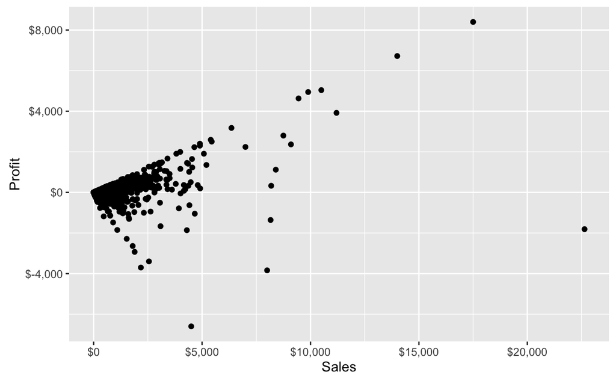

Adding a smooth line to previous scatter plot.

`r`r superstore %>% ggplot(aes(Sales, Profit)) + geom_point() + scale_y_continuous(labels = dollar) + scale_x_continuous(labels = dollar) + geom_smooth()

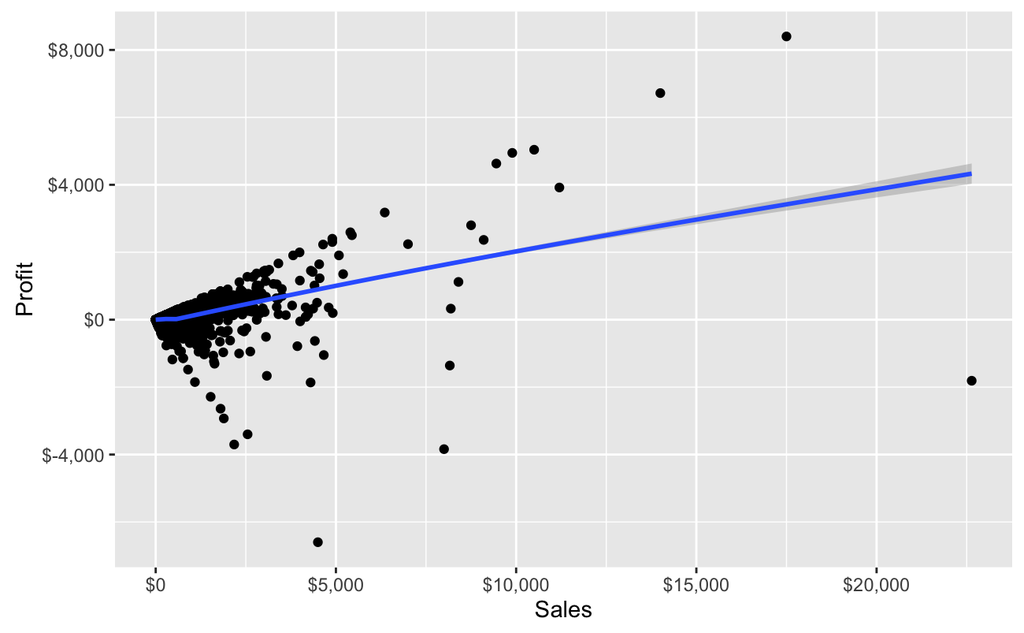

### Histogram

Histogram showing count of quantity.

`r`r superstore %>% ggplot(aes(Quantity)) + geom_histogram()

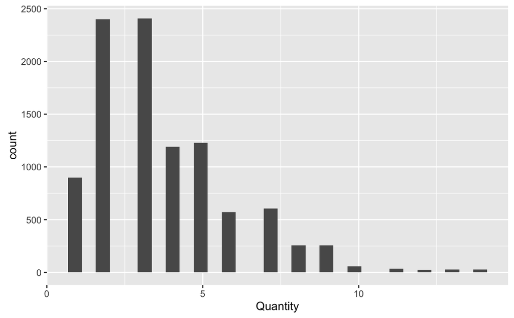

### Boxplot

`r`r superstore %>% ggplot(aes(x = Category, y = Discount)) + geom_boxplot() + scale_y_continuous(labels = percent)

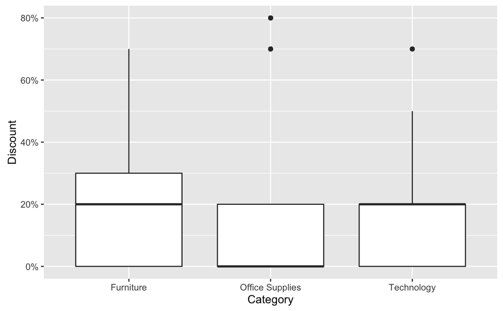

### Faceting

Faceting divides plots into a matrix of panels. Sales by Region.

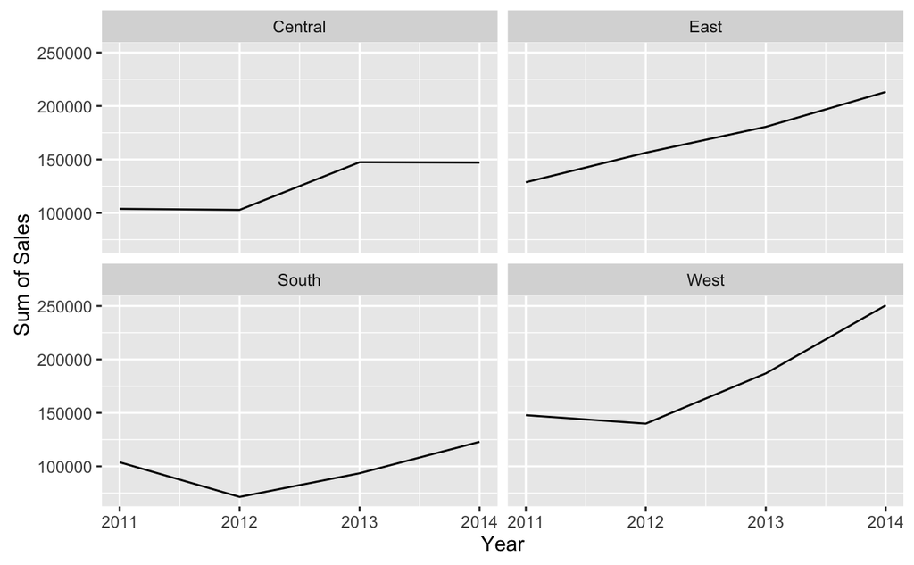